# Initial Exploration

Ori Shoham

2024-05-28

## Setup

```r
rm(list = ls())
gc()
```

```
##          used (Mb) gc trigger (Mb) max used (Mb)
## Ncells 519333 27.8    1153615 61.7   660385 35.3
## Vcells 945680  7.3    8388608 64.0  1769622 13.6
```

```r
library(tidyverse)
library(data.table)
library(haven)
library(glue)
library(tidymodels)
library(vip)
FYC <- fread("datasets/base_Samp_2008_2010.csv")
```

The sample I start with includes panels 13-15 (beginning in 2008-2010). I only include people for whom there is data in both panel years. I am ignoring the family structure of the data for the time being, this means I will not use the survey administrative variables as predictors to avoid leakage of data within the family from train to test sets. One problem I don’t currently address is that for some administrative reasons expenditure variables may represent only a subset of the year for few respondents, handling this will require diving deeper into MEPS sample definitions which seems a bit much for now.

## Expenditure to logs

```r
FYC <- FYC %>%
  mutate(across(c(starts_with("exp"), starts_with("y_exp")),
                .fns = list(log = \(x) log(x+1))))
```

## Split the Data

```r
set.seed(2024)
FYC_split <- initial_split(FYC, prop = 0.5)
FYC_tr <- training(FYC_split)
FYC_test <- testing(FYC_split)
tr_ids <- FYC_tr$surv_ad_DUPERSID
test_ids <- FYC_test$surv_ad_DUPERSID
saveRDS(tr_ids, "interim_objects/sample_split/tr_ids.RDS")
saveRDS(test_ids, "interim_objects/sample_split/test_ids.RDS")
```

## Explore main outcome

To get things started I focus on the variable `y_exp_TOTEXP_y2` and it’s log version which is the total expenditure in the second year.

```r
summary(FYC_tr$y_exp_TOTEXP_y2)
```

```
##    Min. 1st Qu.  Median    Mean 3rd Qu.    Max.
##       0      52     498    3529    2467  616631
```

```r
# proportion 0 expenditure
mean(FYC_tr$y_exp_TOTEXP_y2 == 0)
```

```
## [1] 0.2196339
```

```r
summary(FYC_tr$y_exp_TOTEXP_y2_log)
```

```
##    Min. 1st Qu.  Median    Mean 3rd Qu.    Max.
##   0.000   3.970   6.213   5.409   7.811  13.332
```

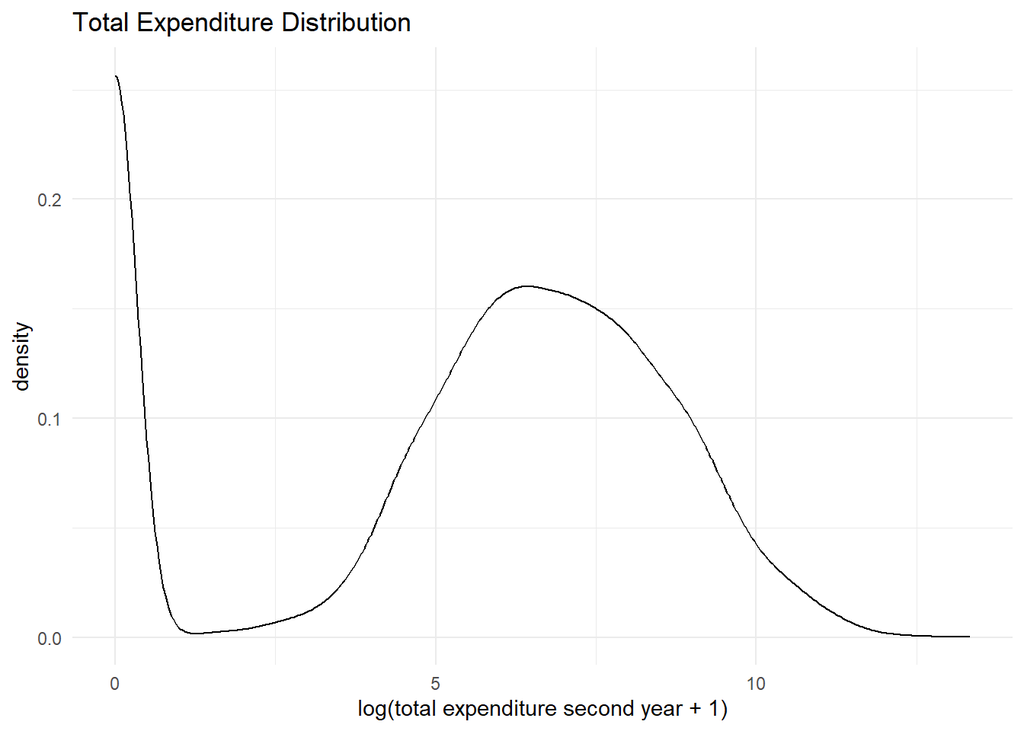

```r
# plot distribution of log total expenditure
FYC_tr %>%
  ggplot(aes(x = y_exp_TOTEXP_y2_log)) +
  geom_density() +
  theme_minimal() +
  labs(x = "log(total expenditure second year + 1)", title = "Total Expenditure Distribution")
```

## A few predictive benchmarks

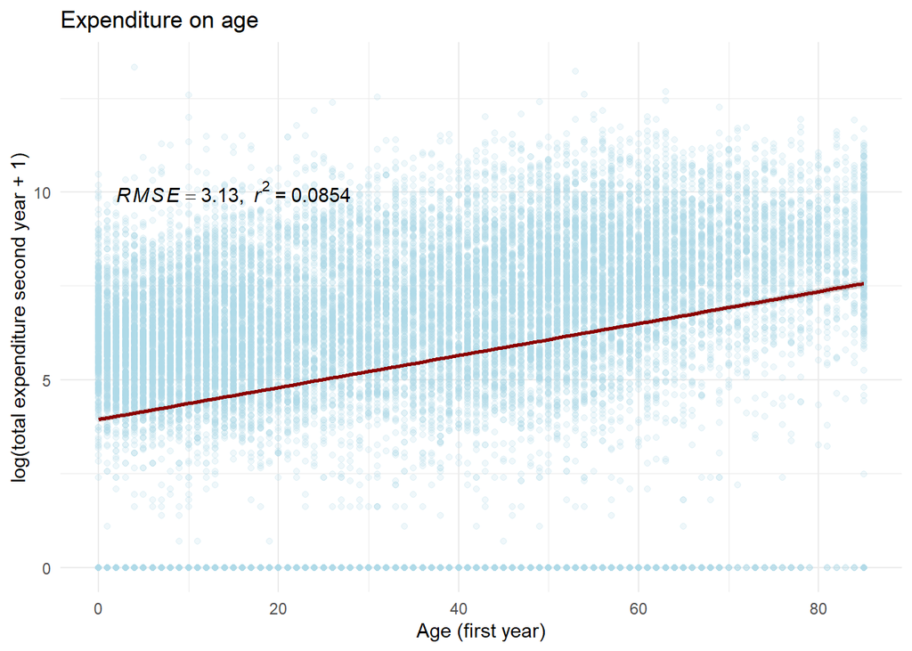

```r
lm_rsq <- function(df, y_var, x_var){
    form <- as.formula(glue("{y_var}~{x_var}"))
    m <- lm(form, df);
    eq <- substitute(italic(RMSE) == rmse*","~~italic(r)^2~"="~r2,
         list(a = format(unname(coef(m)[1]), digits = 2),
              b = format(unname(coef(m)[2]), digits = 2),
             r2 = format(summary(m)$r.squared, digits = 3),
             rmse = format(sqrt(mean(m$residuals^2)), digits = 3)))
    as.character(as.expression(eq));
}



# expenditure and age
FYC_tr %>%
  ggplot(aes(x = dem_AGELAST,y = y_exp_TOTEXP_y2_log)) +
  geom_point(alpha = 0.2, color = "lightblue") +
  theme_minimal() +
  geom_smooth(method = "lm", color = "darkred", linewidth = 1) +
  annotate(geom = "text", x = 15, y = 10, label = lm_rsq(FYC_tr, "y_exp_TOTEXP_y2_log", "dem_AGELAST" ), parse= T) +
  labs(title = "Expenditure on age", x = "Age (first year)", y = "log(total expenditure second year + 1)")
```

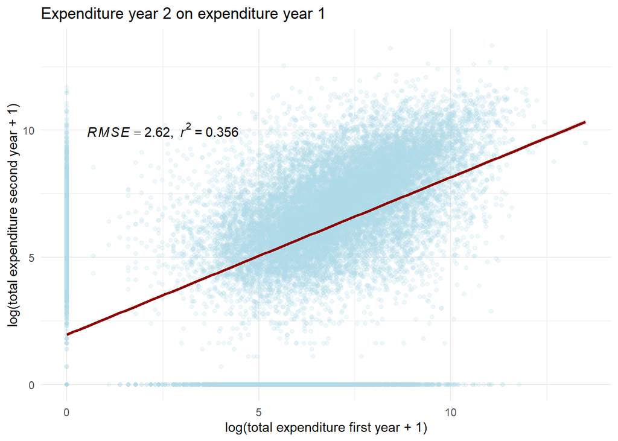

```r
mod_age <- lm(y_exp_TOTEXP_y2_log ~ dem_AGELAST, data = FYC_tr )

# Expenditure y2 on expenditure y1

FYC_tr %>%
  ggplot(aes(x = exp_TOTEXP_y1_log,y = y_exp_TOTEXP_y2_log)) +
  geom_point(alpha = 0.2, color = "lightblue") +
  theme_minimal() +
  geom_smooth(method = "lm", color = "darkred", linewidth = 1) +
  annotate(geom = "text", x = 2.5, y = 10, label = lm_rsq(FYC_tr, "y_exp_TOTEXP_y2_log", "exp_TOTEXP_y1_log" ), parse= T) +
  labs(title = "Expenditure year 2 on expenditure year 1", x = "log(total expenditure first year + 1)", y = "log(total expenditure second year + 1)")
```

```r
mod_exp <- lm(y_exp_TOTEXP_y2_log ~ exp_TOTEXP_y1_log, data = FYC_tr )
```

## Random forest

Start with random forest with all variables except for survey_ad and one without expenditure as well. No feature engineering at all, for now dropping variables with explicit NAs (those are the variables that are not in all three datasets)

```r
set.seed(2023)
# use all predictors
rec_all <- recipe(y_exp_TOTEXP_y2_log ~., data = FYC_tr) %>%
  update_role(starts_with("surv_ad_") & !"surv_ad_PANEL",
              starts_with("y_") & !"y_exp_TOTEXP_y2_log" , contains("_r3"),
              new_role = "discarded") %>%
  step_rm(where(\(x) sum(is.na(x))>0))
# use all predictors except for expenditure in year 1

rec_no_exp <- recipe(y_exp_TOTEXP_y2_log ~., data = FYC_tr) %>%
  update_role(starts_with("surv_ad_") & !"surv_ad_PANEL", starts_with("exp_"),
              starts_with("y_") & !"y_exp_TOTEXP_y2_log" , contains("_r3"),
              new_role = "discarded")%>%
  step_rm(where(\(x) sum(is.na(x))>0))


mod_rf <- rand_forest(mode = "regression") %>%
  set_engine("randomForest")

rec_list <- list(rec_all, rec_no_exp)

workflow_all <- workflow() %>%
  add_recipe(rec_all) %>%
  add_model(mod_rf)

workflow_no_exp <- workflow() %>%
  add_recipe(rec_no_exp) %>%
  add_model(mod_rf)
```

```r
fit_all <- fit(workflow_all, FYC_tr)
fit_no_exp <- fit(workflow_no_exp, FYC_tr)

saveRDS(fit_all, "interim_objects/models/rf_all_pred_13_15_unproc.RDS")
saveRDS(fit_no_exp, "interim_objects/models/rf_no_exp_13_15_unproc.RDS")
```

```r
fit_all <- readRDS("interim_objects/models/rf_all_pred_13_15_unproc.RDS")
fit_no_exp <- readRDS("interim_objects/models/rf_no_exp_13_15_unproc.RDS")

results <- fit_all %>%
  predict(FYC_tr) %>%
  mutate(truth = FYC_tr$y_exp_TOTEXP_y2_log, predictors = "all", data = "train") %>%
  bind_rows(fit_all %>%
    predict(FYC_test) %>%
    mutate(truth = FYC_test$y_exp_TOTEXP_y2_log, predictors = "all", data = "test")) %>%
  bind_rows(fit_no_exp %>%
    predict(FYC_tr) %>%
    mutate(truth = FYC_tr$y_exp_TOTEXP_y2_log, predictors = "no_exp", data = "train")) %>%
  bind_rows(fit_no_exp %>%
    predict(FYC_test) %>%
    mutate(truth = FYC_test$y_exp_TOTEXP_y2_log, predictors = "no_exp", data = "test")) %>%
  bind_rows(mod_age %>%
              predict(FYC_tr) %>%
              tibble( ) %>%
              rename(.pred = ".") %>%
              mutate(truth = FYC_tr$y_exp_TOTEXP_y2_log, predictors = "age_lm", data = "train")) %>%
  bind_rows(mod_age %>%
              predict(FYC_test) %>%
              tibble( ) %>%
              rename(.pred = ".") %>%
              mutate(truth = FYC_test$y_exp_TOTEXP_y2_log, predictors = "age_lm", data = "test")) %>%
  bind_rows(mod_exp %>%
              predict(FYC_tr) %>%
              tibble( ) %>%
              rename(.pred = ".") %>%
              mutate(truth = FYC_tr$y_exp_TOTEXP_y2_log, predictors = "exp_lm", data = "train")) %>%
  bind_rows(mod_exp %>%
              predict(FYC_test) %>%
              tibble( ) %>%
              rename(.pred = ".") %>%
              mutate(truth = FYC_test$y_exp_TOTEXP_y2_log, predictors = "exp_lm", data = "test"))

res_sum <- results %>%
  group_by(predictors, data) %>%
  rmse(truth = truth, estimate = .pred) %>%
  bind_rows(results %>%
    group_by(predictors, data) %>%
    rsq(truth = truth, estimate = .pred)) %>%
  pivot_wider(names_from = c(data, .metric), values_from = .estimate) %>%
  select(!.estimator)

res_sum[c(1,3,2,4),] %>%
  select(predictors, train_rmse, test_rmse, train_rsq, test_rsq)
```

```
## # A tibble: 4 × 5
##   predictors train_rmse test_rmse train_rsq test_rsq
##   <chr>           <dbl>     <dbl>     <dbl>    <dbl>
## 1 age_lm          3.13       3.12    0.0854   0.0880
## 2 exp_lm          2.62       2.64    0.356    0.347
## 3 all             0.957      2.40    0.940    0.460
## 4 no_exp          0.962      2.40    0.940    0.461
```

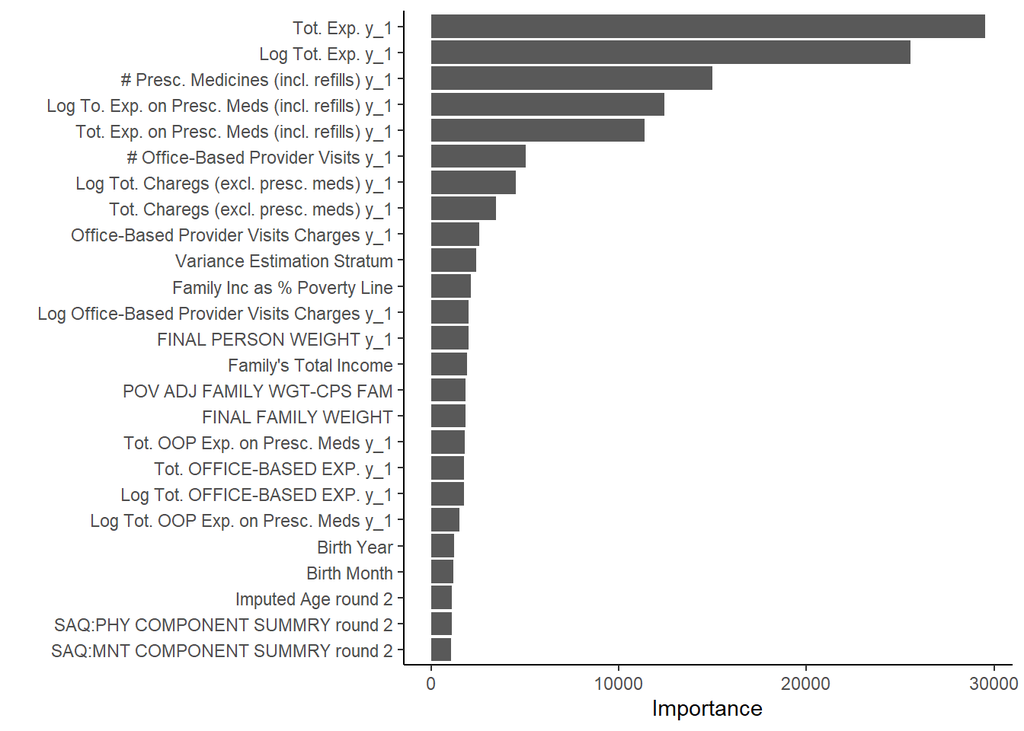

```r
# variable importance all predictors
imp_all <- fit_all %>%
  vip(num_features = 25)

orig_var_names <- imp_all$data$Variable

imp_all$data$Variable <-
  c("Tot. Exp. y_1", "Log Tot. Exp. y_1", "# Presc. Medicines (incl. refills) y_1",
    "Log To. Exp. on Presc. Meds (incl. refills) y_1", "Tot. Exp. on Presc. Meds (incl. refills) y_1",
    "# Office-Based Provider Visits y_1", "Log Tot. Charegs (excl. presc. meds) y_1",
    "Tot. Charegs (excl. presc. meds) y_1", "Office-Based Provider Visits Charges y_1", "Variance Estimation Stratum",
    "Family Inc as % Poverty Line", "Log Office-Based Provider Visits Charges y_1", "FINAL PERSON WEIGHT y_1",
    "Family's Total Income", "POV ADJ FAMILY WGT-CPS FAM", "FINAL FAMILY WEIGHT", "Tot. OOP Exp. on Presc. Meds y_1",
    "Tot. OFFICE-BASED EXP. y_1", "Log Tot. OFFICE-BASED EXP. y_1",  "Log Tot. OOP Exp. on Presc. Meds y_1", "Birth Year",
    "Birth Month", "Imputed Age round 2", "SAQ:PHY COMPONENT SUMMRY round 2", "SAQ:MNT COMPONENT SUMMRY round 2")
imp_all +
  theme_classic()
```

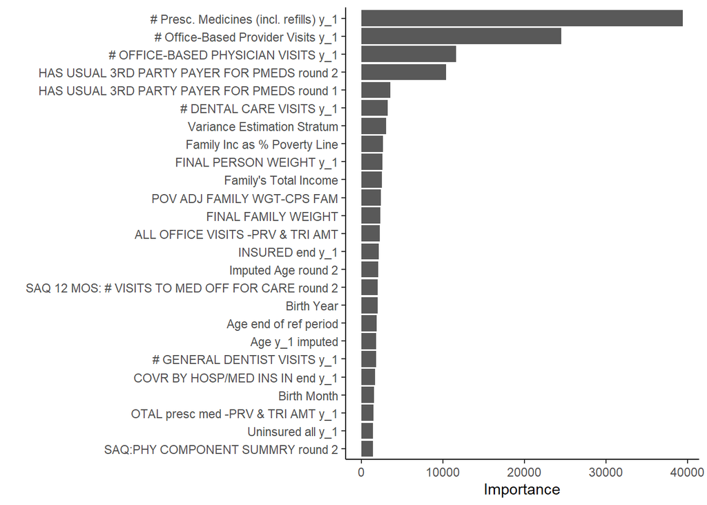

```r
# variable importance no expenditure
imp_no_exp <- fit_no_exp %>%
  vip(num_features = 25)

for(x in imp_no_exp$data$Variable ){
  if (x %in% orig_var_names){
    imp_no_exp$data$Variable[imp_no_exp$data$Variable == x] <- imp_all$data$Variable[orig_var_names == x]
  }
}
imp_no_exp$data$Variable[c(3,4,5,6,13,14,16,18,19,20,21,23,24) ] <- c(
  "# OFFICE-BASED PHYSICIAN VISITS y_1", "HAS USUAL 3RD PARTY PAYER FOR PMEDS round 2",
  "HAS USUAL 3RD PARTY PAYER FOR PMEDS round 1", "# DENTAL CARE VISITS y_1", "ALL OFFICE VISITS -PRV & TRI AMT",
  "INSURED end y_1", "SAQ 12 MOS: # VISITS TO MED OFF FOR CARE round 2",
  "Age end of ref period", "Age y_1 imputed", "# GENERAL DENTIST VISITS y_1", "COVR BY HOSP/MED INS IN end y_1",
  "OTAL presc med -PRV & TRI AMT y_1", "Uninsured all y_1"
)

imp_no_exp +
  theme_classic()
```